# Datathon 2023: Investigating Airline Delays During College Student Travel in the 5Cs

2023-10-21

## By Haram Yoon and Kartika Santonso

College students often experience the frustration of delayed flights when traveling home for academic breaks. As students book tickets home for the holidays, they want to choose airlines that are less likely to experience delays departing from major college town airports.

In this report, we analyzed airline flight data to uncover insights into delay rates for different carriers around college student travel periods. They focused on flights leaving college town airports during the typical breaks within the academic calendar.

The goal was to identify airlines that tend to have higher versus lower delays when serving college student travelers. The findings can help students make informed decisions when booking flights home for Thanksgiving, winter break, spring break, and other peak travel times.

We loaded historical flight data into R and filtered for flights departing from the major airports, Ontario and LAX, near the 5cs. We calculated delay rates for different airlines during the busy student travel periods. Finally, we visualized the airline delay patterns to highlight carriers with relatively high and low delays.

The report outlines the analysis process and key findings. The results provide data-driven guidance to help college students choose airlines with the best on-time reliability when planning trips home.

### Delay Rates for Major Carriers During Holiday Travel Out of LAX and Ontario

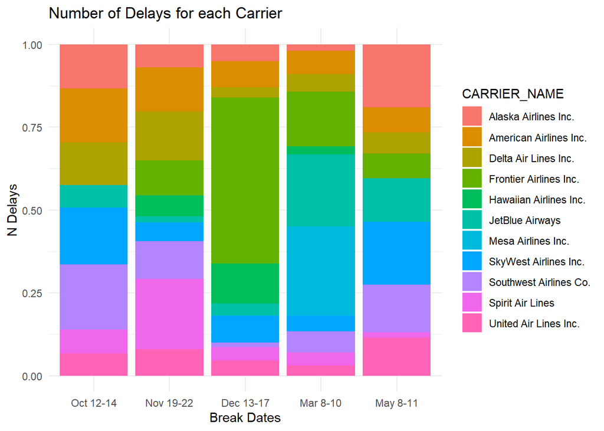

This chart shows the relative delay rates for major carriers during the specified holiday travel periods out of LAX and Ontario. We can see that some carriers experienced higher delays than others during the busy travel times. This information could help college student choose the best airline for holidays from the 5Cs. For example, Frontier Airlines have a big proportion of the delays found before winter break. Companies such as United consistently stay on the lower proportions of delays regardless of seasons. Our plot will help 5c students to figure out which airlines are more likely to have delays per break.

### Exploring Airline Delay Patterns for Student Travel

To dig deeper into airline delays during student travel periods, I calculated the average delay time for flights departing college towns during academic breaks.

First, I filtered the data to only include flights leaving LAX or Ontario airports, and limited to the break travel periods previously identified. I then grouped the flights by origin city, destination, and airline carrier. For each group, I calculated the total delay, number of flights, and mean delay time. Finally, I visualized the mean delay time for each airline and destination as a faceted dot plot w margins of errors.

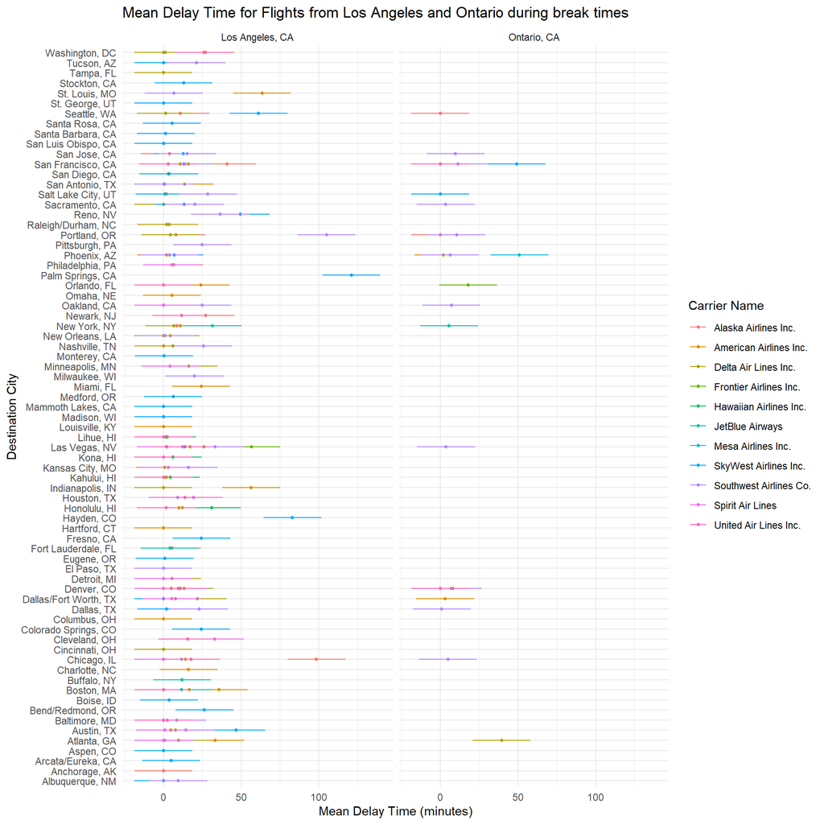

This visualization highlights the carriers and destinations with the lowest and highest average delays during student travel periods. Students can use this to make more informed airline selections when booking flights home from college. This is help college students figure out which airline to take from either the Ontario and LAX. It even tells us which airlines are historically available at these airports and their mean delay times. For example, if you go to Chicago from LAX, Alaska Airlines should not be your first option.

### Mapping Delays in Arriving Flights to LAX and ONT

[interactive chart not shown]

Next, we took a subset of the dataset containing only flights arriving at LAX or ONT, and visualized these flights.

This interactive map visualizes all flights arriving at LAX and ONT from every other airport in the US. Each airport is colored based on the mean delay that flights to LAX and ONT experience. If you click on the points, you will be able to see the airport name, the number of flights to LAX and ONT, and the mean delay for these flights.

This allows Claremont College students to see which flight routes may experience delays, which would allow them to better select flights to take when returning home over breaks.

### Ethics

We acknowledge that in generalizing flight delays for airlines and routes, this could result in a loss of sales for these airlines and paths, which could ultimately impact workers for these airlines. We also realize that since we are using past data, it isn’t indictative of future and present conditions for these airlines and routes.

## Github Link

https://github.com/haram082/datathon.git